# IDS investigation worksheet

by GitChuds: Ethan, Miles, Freddie, Daniel & Zack

2026-11-27

**Note:** You can use this file as you ‘working document’ where you can try out various investigation ideas and keep notes about your findings. How you use and structure this file is up to you. It is recommended that you keep notes about what you are investigating and what you find as this will make the process of creating your presentation and report easier. Please note that you *do not* need to submit this file as part of your group project.

```r
library(tidyverse)
# Add any other libraries here
library(readr)
library(janitor)
library(ggplot2)
library(scales)
library(lubridate)
library(rsample)
```

| Raw Variable Name | Clean Variable Name | Data Type | Numerical or Categorical | Description & Units |
| --- | --- | --- | --- | --- |
| **Date** | date | chr | categorical | date in year-month-day format |
| **Rented Bike Count** | rented_bike_count | dbl | numerical | count of bikes rented at each hour |
| **Hour** | hour | dbl | numerical | hour of the day |
| **Temperature** | temperature_c | dbl | numerical | temperature in Celsius |
| **Humidity** | humidity_percent | dbl | numerical | humidity in percentage |
| **Wind Speed** | wind_speed_m_s | dbl | numerical | wind speed in m/s |
| **Visibility** | visibility_10m | dbl | numerical | visibility in 10m units |
| **Dew Point Temperature** | dew_point_temperature_c | dbl | numerical | dew point temperature - temperature at which the air needs to be cooled to (at constant pressure) in order to achieve a relative humidity |
| **Solar Radiation** | solar_radiation_mj_m2 | dbl | numerical | solar radiation in MJ/M^2 |
| **Rainfall** | rainfall_mm | dbl | numerical | rainfall in mm |
| **Snowfall** | snowfall_cm | dbl | numerical | snowfall in cm |
| **Seasons** | seasons | chr | categorical | represents the four seasons |
| **Holiday** | holiday | chr | categorical | holiday or no holiday |
| **Functioning Day** | functioning_day | chr | categorical | yes or no; represents if system is fully operational or not |

## Questions

1. Does temperature affect bike demand differently during peak commuting hours (8-9am and 6-7pm) compared to off-peak hours?
2. Is the holiday effect uniform across seasons, or do holiday demand patterns shift significantly between the seasons?
3. Is there a sharp threshold or non-linear drop-off point where precipitation severly degrades demand, or is the decay linear?
4. How do temperature and humidity combine to affect demand (compared to just considering temperature)?
5. How does the hourly distribution shift between a regular working day and a non-working day?

## Loading and Cleaning Data

```r
# load data
seoul_bikes_raw <- read_csv("data/SeoulBikeData.csv", locale=locale(encoding="latin1"))
#extracting raw data, locale needed to be specified as error otherwise.

#clean data
seoul_bikes <- seoul_bikes_raw |>
  clean_names()
#cleaning names to snake_case, as column headings' words initially separated with space

#looking above at the variable table, it might mean that on non-functional days, there will be no bikes rented whatsoever. We run the following code to verify:
#seoul_bikes |> filter(functioning_day == "No" & rented_bike_count > 0)

seoul_bikes <- seoul_bikes |>
  filter(functioning_day != "No") |>
  select(-functioning_day)
#after dropping non-functioning days, we can drop the functioning_day variable entirely, as it has become redundant.

seoul_bikes
```

```
## # A tibble: 8,465 × 13
##    date    rented_bike_count  hour temperature_c humidity_percent wind_speed_m_s
##    <chr>               <dbl> <dbl>         <dbl>            <dbl>          <dbl>
##  1 01/12/…               254     0          -5.2               37            2.2
##  2 01/12/…               204     1          -5.5               38            0.8
##  3 01/12/…               173     2          -6                 39            1
##  4 01/12/…               107     3          -6.2               40            0.9
##  5 01/12/…                78     4          -6                 36            2.3
##  6 01/12/…               100     5          -6.4               37            1.5
##  7 01/12/…               181     6          -6.6               35            1.3
##  8 01/12/…               460     7          -7.4               38            0.9
##  9 01/12/…               930     8          -7.6               37            1.1
## 10 01/12/…               490     9          -6.5               27            0.5
## # ℹ 8,455 more rows
## # ℹ 7 more variables: visibility_10m <dbl>, dew_point_temperature_c <dbl>,
## #   solar_radiation_mj_m2 <dbl>, rainfall_mm <dbl>, snowfall_cm <dbl>,
## #   seasons <chr>, holiday <chr>
```

## Task 1 - Investigating the Effect of Temperature of Number of Rented Bikes During Peak or Non-Peak Hours

### 1.1 Data Wrangling

We define peak commuting hours as 7-9am and 5-7pm

```r
#Task 1
seoul_bikes <- seoul_bikes |>
  mutate(
    peak = ifelse(hour %in% c(7:9, 17:19), TRUE, FALSE)
    #used Gemini to help with shortening the conditional statement, as initially was hour == 7 | hour == 8 | ...
  )
```

### 1.2a Data Visualisation (Scatterplot)

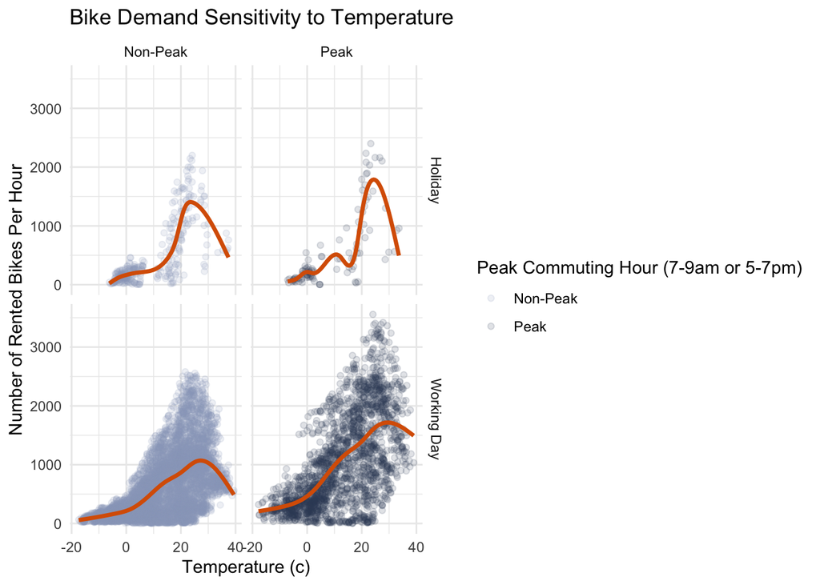

```r
#Task 1 - evaluating temperature sensitivty during peak hours vs. off-peak hours
seoul_bikes |>
  ggplot(aes(x = temperature_c, y = rented_bike_count)) +
  geom_jitter(
    aes(colour = peak),
    alpha = 0.15
  ) +
  geom_smooth(
    method = "gam",
    se = FALSE,
    linewidth = 1.2,
    colour = "#d95f02"
    ) +
  facet_grid( #changed to facet_grid to take holidays into account, not taking weekdays vs. weekends into account as there many weekend workers in Seoul who may need to commute
    holiday ~ peak,
    labeller = as_labeller(c("TRUE" = "Peak", "FALSE" = "Non-Peak", "Holiday" = "Holiday", "No Holiday" = "Working Day"))
    ) +
  #changes labels from facetting to "Peak" and "Non-Peak"
  theme_minimal() +
  scale_colour_manual(
    guide = "legend",
    values = c("TRUE" = "#384860", "FALSE" = "#97a6c4"), #changed colour to lighter shades, as otherwise points are too dark
    labels = c("TRUE" = "Peak", "FALSE" = "Non-Peak")
    ) +
  guides(alpha = "none") +
  labs(
    x = "Temperature (c)",
    y = "Number of Rented Bikes Per Hour",
    colour = "Peak Commuting Hour (7-9am or 5-7pm)",
    title = "Bike Demand Sensitivity to Temperature"
  )
```

From the difference in the opacities/ darkness of each scatterplot, we can see that the dataset contains many more entries for non-peak hours than peak hours.

We can also see this from the following code:

```r
seoul_bikes |>
  group_by(peak) |>
  count()
```

```
## # A tibble: 2 × 2
## # Groups:   peak [2]
##   peak      n
##   <lgl> <int>
## 1 FALSE  6347
## 2 TRUE   2118
```

However, we can already see there might be similarities in the pattern or the shape of the data represented above, where unimodal, asymmetric clusters can be seen for the two groups.

From the points during peak commuting hours, we see its maximum is much higher than that of the non-peak hours, the values specifically are 3556 vs. 2579 bikes/ hour.

On average, we also see that the number of rented bikes per hour is significantly higher during peak hours, with the means being approx. 1052 vs. 621, and the medians being 867 vs. 440.

Additionally, if we consider the GAM line on the scatterplot, we see that the line for the peak hours are much steeper than that of the non-peak hours, which may suggest that temperature acts as a stronger multiplier during peak hours.

We also see that the resiliance of commuters during lower temperatures (colder weather) at peak times is stronger, this would imply that commuters are less likely to not commute with bikes, as they must get to work or get to school on time. Conversely, for those during off-peak hours, the lower coldness tolerance may suggest they are less reliant on renting bikes and may choose to stay indoors or opt for another form of transport entirely.

Back to the similarities, we see that at high heat, the number of rented bikes per hour drop off. This means that once a threshold of around 30 degrees C is hit, even the peak commuters will choose another way of commuting, likely travelling with transportation offerring air-conditioning, e.g. busses or the metro.

```r
seoul_bikes |>
  group_by(peak) |>
  summarise(
    max = max(rented_bike_count),
    min = min(rented_bike_count),
    mean = mean(rented_bike_count),
    median = median(rented_bike_count),
    sd = sd(rented_bike_count),
    iqr = IQR(rented_bike_count)
  )
```

```
## # A tibble: 2 × 7
##   peak    max   min  mean median    sd   iqr
##   <lgl> <dbl> <dbl> <dbl>  <dbl> <dbl> <dbl>
## 1 FALSE  2579     2  621.    440  540.  772
## 2 TRUE   3556     3 1052.    867  798. 1290.
```

To be more specific, we shall analyse the distribution of the data, we should instead consider the density plots:

```r
determine_density_maxes <- function(df, max_var, max_var_condition, density_var){ #parameters to keep generality of function
  density_df <- df |>
    filter({{ max_var }} == max_var_condition) |>
    pull({{ density_var }}) |>
    density() |>
    (\(d) tibble::tibble(x = d$x, y = d$y))()
    #creating a separate data frame for density values

    high_peak <- density_df |> filter(y == max(y))
    low_peak <- density_df |> filter(x < 15) |> filter(y == max(y))

    tibble::tibble(
      max_y_high = high_peak$y,
      x_at_max_y_high = high_peak$x,
      max_y_low = low_peak$y,
      x_at_max_y_low = low_peak$x
    )
    #returns values in tibble form

}
#needed to use {{}} as passing in the column names and not variable objects - Gemini was used, as it was initially causing errors

peak_maxes<- determine_density_maxes(seoul_bikes, peak, TRUE, temperature_c)
non_peak_maxes <- determine_density_maxes(seoul_bikes, peak, FALSE, temperature_c)

peak_maxes
```

```
## # A tibble: 1 × 4
##   max_y_high x_at_max_y_high max_y_low x_at_max_y_low
##        <dbl>           <dbl>     <dbl>          <dbl>
## 1     0.0297            22.1    0.0250           3.56
```

```r
non_peak_maxes
```

```
## # A tibble: 1 × 4
##   max_y_high x_at_max_y_high max_y_low x_at_max_y_low
##        <dbl>           <dbl>     <dbl>          <dbl>
## 1     0.0317            21.1    0.0255           4.94
```